# Project4

The dataset contains information about payment failures, demographic factors, credit data, payment history, and billing statements of credit card clients in Taiwan from April 2005 to September 2005.

There are 25 variables:

- ID: ID of each client
- LIMIT_BAL: Amount of credits granted in NT dollars (includes individual and family/additional credits
- SEX: Gender (1=male, 2=female)
- EDUCATION: (1=S2, 2=university, 3=high school, 4=other, 5=unknown, 6=unknown)
- MARRIAGE: Marital status (1=married, 2=single, 3=other)
- AGE: Age in years
- PAY_0: Payment status for September 2005 (-1=paid in full, 1=payment delay for one month, 2=payment delay for two months, ... 8=payment delay for eight months, 9=payment delay for nine months and on)
- PAY_2: Repayment status in August 2005 (same scale as above)
- PAY_3: Repayment status in July 2005 (same scale as above)
- PAY_4: Repayment status in June 2005 (same scale as above)
- PAY_5: Repayment status in May 2005 (same scale as above)
- PAY_6: Repayment status in April 2005 (same scale as above)
- BILL_AMT1: Billing statement amount for September 2005 (NT dollars)
- BILL_AMT2 : Billing amount for August 2005 (NT Dollars)
- BILL_AMT3: Billing statement amount for July 2005 (NT Dollars)
- BILL_AMT4: Billing statement amount for June 2005 (NT Dollars)
- BILL_AMT5: Billing amount for May 2005 (NT Dollars)
- BILL_AMT6: Billing statement amount for April 2005 (NT Dollars)
- PAY_AMT1: Previous payment amount in September 2005 (NT dollars)
- PAY_AMT2: Previous payment amount in August 2005 (NT Dollars)
- PAY_AMT3: Previous payment amount in July 2005 (NT dollars)
- PAY_AMT4: Previous payment amount in June 2005 (NT Dollars)
- PAY_AMT5: Previous payment amount in May 2005 (NT dollars)
- PAY_AMT6: Previous payment amount in April 2005 (NT dollars) default.payment.next month: Default payment (1=yes, 0=no)

Complete the tasks below:

EDA

```python
import pandas as pd
import numpy as np
import seaborn as sns
import matplotlib.pyplot as plt
```

```python
credit_df = pd.read_csv('UCI_Credit_Card.csv')
```

```python
credit_df
```

|  | ID | LIMIT_BAL | SEX | EDUCATION | MARRIAGE | AGE | PAY_0 | PAY_2 | PAY_3 | PAY_4 | ... | BILL_AMT4 | BILL_AMT5 | BILL_AMT6 | PAY_AMT1 | PAY_AMT2 | PAY_AMT3 | PAY_AMT4 | PAY_AMT5 | PAY_AMT6 | default.payment.next.month |
| --- | --- | --- | --- | --- | --- | --- | --- | --- | --- | --- | --- | --- | --- | --- | --- | --- | --- | --- | --- | --- | --- |
| 0 | 1 | 20000.0 | 2 | 2 | 1 | 24 | 2 | 2 | -1 | -1 | ... | 0.0 | 0.0 | 0.0 | 0.0 | 689.0 | 0.0 | 0.0 | 0.0 | 0.0 | 1 |
| 1 | 2 | 120000.0 | 2 | 2 | 2 | 26 | -1 | 2 | 0 | 0 | ... | 3272.0 | 3455.0 | 3261.0 | 0.0 | 1000.0 | 1000.0 | 1000.0 | 0.0 | 2000.0 | 1 |
| 2 | 3 | 90000.0 | 2 | 2 | 2 | 34 | 0 | 0 | 0 | 0 | ... | 14331.0 | 14948.0 | 15549.0 | 1518.0 | 1500.0 | 1000.0 | 1000.0 | 1000.0 | 5000.0 | 0 |
| 3 | 4 | 50000.0 | 2 | 2 | 1 | 37 | 0 | 0 | 0 | 0 | ... | 28314.0 | 28959.0 | 29547.0 | 2000.0 | 2019.0 | 1200.0 | 1100.0 | 1069.0 | 1000.0 | 0 |
| 4 | 5 | 50000.0 | 1 | 2 | 1 | 57 | -1 | 0 | -1 | 0 | ... | 20940.0 | 19146.0 | 19131.0 | 2000.0 | 36681.0 | 10000.0 | 9000.0 | 689.0 | 679.0 | 0 |
| ... | ... | ... | ... | ... | ... | ... | ... | ... | ... | ... | ... | ... | ... | ... | ... | ... | ... | ... | ... | ... | ... |
| 29995 | 29996 | 220000.0 | 1 | 3 | 1 | 39 | 0 | 0 | 0 | 0 | ... | 88004.0 | 31237.0 | 15980.0 | 8500.0 | 20000.0 | 5003.0 | 3047.0 | 5000.0 | 1000.0 | 0 |
| 29996 | 29997 | 150000.0 | 1 | 3 | 2 | 43 | -1 | -1 | -1 | -1 | ... | 8979.0 | 5190.0 | 0.0 | 1837.0 | 3526.0 | 8998.0 | 129.0 | 0.0 | 0.0 | 0 |
| 29997 | 29998 | 30000.0 | 1 | 2 | 2 | 37 | 4 | 3 | 2 | -1 | ... | 20878.0 | 20582.0 | 19357.0 | 0.0 | 0.0 | 22000.0 | 4200.0 | 2000.0 | 3100.0 | 1 |
| 29998 | 29999 | 80000.0 | 1 | 3 | 1 | 41 | 1 | -1 | 0 | 0 | ... | 52774.0 | 11855.0 | 48944.0 | 85900.0 | 3409.0 | 1178.0 | 1926.0 | 52964.0 | 1804.0 | 1 |
| 29999 | 30000 | 50000.0 | 1 | 2 | 1 | 46 | 0 | 0 | 0 | 0 | ... | 36535.0 | 32428.0 | 15313.0 | 2078.0 | 1800.0 | 1430.0 | 1000.0 | 1000.0 | 1000.0 | 1 |

30000 rows × 25 columns

```python
credit_df.isna().sum()
```

```
ID                            0
LIMIT_BAL                     0
SEX                           0
EDUCATION                     0
MARRIAGE                      0
AGE                           0
PAY_0                         0
PAY_2                         0
PAY_3                         0
PAY_4                         0
PAY_5                         0
PAY_6                         0
BILL_AMT1                     0
BILL_AMT2                     0
BILL_AMT3                     0
BILL_AMT4                     0
BILL_AMT5                     0
BILL_AMT6                     0
PAY_AMT1                      0
PAY_AMT2                      0
PAY_AMT3                      0
PAY_AMT4                      0
PAY_AMT5                      0
PAY_AMT6                      0
default.payment.next.month    0
dtype: int64
```

```python
credit_df.info()
```

```
<class 'pandas.core.frame.DataFrame'>
RangeIndex: 30000 entries, 0 to 29999
Data columns (total 25 columns):
 #   Column                      Non-Null Count  Dtype
---  ------                      --------------  -----
 0   ID                          30000 non-null  int64
 1   LIMIT_BAL                   30000 non-null  float64
 2   SEX                         30000 non-null  int64
 3   EDUCATION                   30000 non-null  int64
 4   MARRIAGE                    30000 non-null  int64
 5   AGE                         30000 non-null  int64
 6   PAY_0                       30000 non-null  int64
 7   PAY_2                       30000 non-null  int64
 8   PAY_3                       30000 non-null  int64
 9   PAY_4                       30000 non-null  int64
```

[output cut: 17 more lines]

```python
credit_df.columns
```

```
Index(['ID', 'LIMIT_BAL', 'SEX', 'EDUCATION', 'MARRIAGE', 'AGE', 'PAY_0',
       'PAY_2', 'PAY_3', 'PAY_4', 'PAY_5', 'PAY_6', 'BILL_AMT1', 'BILL_AMT2',
       'BILL_AMT3', 'BILL_AMT4', 'BILL_AMT5', 'BILL_AMT6', 'PAY_AMT1',
       'PAY_AMT2', 'PAY_AMT3', 'PAY_AMT4', 'PAY_AMT5', 'PAY_AMT6',
       'default.payment.next.month'],
      dtype='object')
```

```python
credit_df.describe()
```

|  | ID | LIMIT_BAL | SEX | EDUCATION | MARRIAGE | AGE | PAY_0 | PAY_2 | PAY_3 | PAY_4 | ... | BILL_AMT4 | BILL_AMT5 | BILL_AMT6 | PAY_AMT1 | PAY_AMT2 | PAY_AMT3 | PAY_AMT4 | PAY_AMT5 | PAY_AMT6 | default.payment.next.month |
| --- | --- | --- | --- | --- | --- | --- | --- | --- | --- | --- | --- | --- | --- | --- | --- | --- | --- | --- | --- | --- | --- |
| count | 30000.000000 | 30000.000000 | 30000.000000 | 30000.000000 | 30000.000000 | 30000.000000 | 30000.000000 | 30000.000000 | 30000.000000 | 30000.000000 | ... | 30000.000000 | 30000.000000 | 30000.000000 | 30000.000000 | 3.000000e+04 | 30000.00000 | 30000.000000 | 30000.000000 | 30000.000000 | 30000.000000 |
| mean | 15000.500000 | 167484.322667 | 1.603733 | 1.853133 | 1.551867 | 35.485500 | -0.016700 | -0.133767 | -0.166200 | -0.220667 | ... | 43262.948967 | 40311.400967 | 38871.760400 | 5663.580500 | 5.921163e+03 | 5225.68150 | 4826.076867 | 4799.387633 | 5215.502567 | 0.221200 |
| std | 8660.398374 | 129747.661567 | 0.489129 | 0.790349 | 0.521970 | 9.217904 | 1.123802 | 1.197186 | 1.196868 | 1.169139 | ... | 64332.856134 | 60797.155770 | 59554.107537 | 16563.280354 | 2.304087e+04 | 17606.96147 | 15666.159744 | 15278.305679 | 17777.465775 | 0.415062 |
| min | 1.000000 | 10000.000000 | 1.000000 | 0.000000 | 0.000000 | 21.000000 | -2.000000 | -2.000000 | -2.000000 | -2.000000 | ... | -170000.000000 | -81334.000000 | -339603.000000 | 0.000000 | 0.000000e+00 | 0.00000 | 0.000000 | 0.000000 | 0.000000 | 0.000000 |
| 25% | 7500.750000 | 50000.000000 | 1.000000 | 1.000000 | 1.000000 | 28.000000 | -1.000000 | -1.000000 | -1.000000 | -1.000000 | ... | 2326.750000 | 1763.000000 | 1256.000000 | 1000.000000 | 8.330000e+02 | 390.00000 | 296.000000 | 252.500000 | 117.750000 | 0.000000 |
| 50% | 15000.500000 | 140000.000000 | 2.000000 | 2.000000 | 2.000000 | 34.000000 | 0.000000 | 0.000000 | 0.000000 | 0.000000 | ... | 19052.000000 | 18104.500000 | 17071.000000 | 2100.000000 | 2.009000e+03 | 1800.00000 | 1500.000000 | 1500.000000 | 1500.000000 | 0.000000 |
| 75% | 22500.250000 | 240000.000000 | 2.000000 | 2.000000 | 2.000000 | 41.000000 | 0.000000 | 0.000000 | 0.000000 | 0.000000 | ... | 54506.000000 | 50190.500000 | 49198.250000 | 5006.000000 | 5.000000e+03 | 4505.00000 | 4013.250000 | 4031.500000 | 4000.000000 | 0.000000 |
| max | 30000.000000 | 1000000.000000 | 2.000000 | 6.000000 | 3.000000 | 79.000000 | 8.000000 | 8.000000 | 8.000000 | 8.000000 | ... | 891586.000000 | 927171.000000 | 961664.000000 | 873552.000000 | 1.684259e+06 | 896040.00000 | 621000.000000 | 426529.000000 | 528666.000000 | 1.000000 |

8 rows × 25 columns

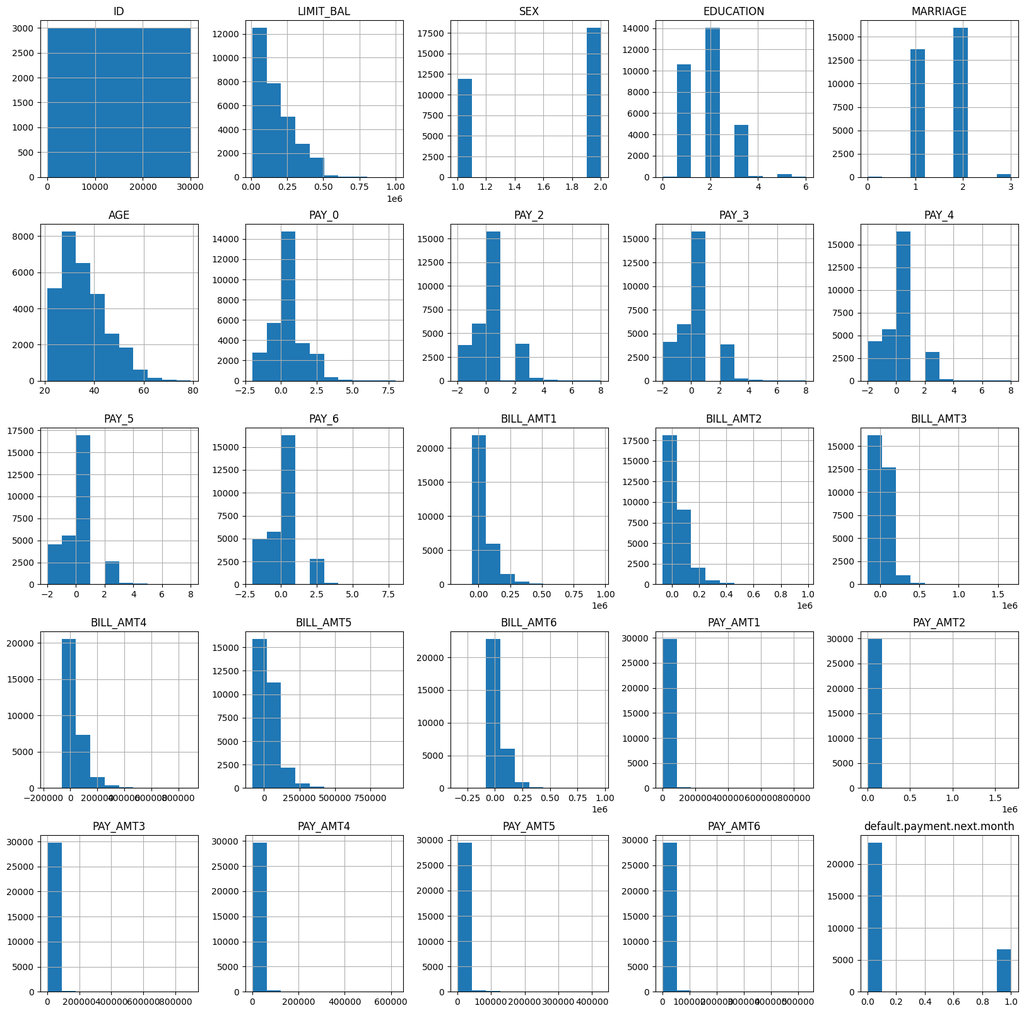

```python
credit_df.hist(figsize=(20,20))
plt.show()
```

```python
credit_df.drop(['ID'], axis = 1, inplace = True)
```

```python
credit_df
```

|  | LIMIT_BAL | SEX | EDUCATION | MARRIAGE | AGE | PAY_0 | PAY_2 | PAY_3 | PAY_4 | PAY_5 | ... | BILL_AMT4 | BILL_AMT5 | BILL_AMT6 | PAY_AMT1 | PAY_AMT2 | PAY_AMT3 | PAY_AMT4 | PAY_AMT5 | PAY_AMT6 | default.payment.next.month |
| --- | --- | --- | --- | --- | --- | --- | --- | --- | --- | --- | --- | --- | --- | --- | --- | --- | --- | --- | --- | --- | --- |
| 0 | 20000.0 | 2 | 2 | 1 | 24 | 2 | 2 | -1 | -1 | -2 | ... | 0.0 | 0.0 | 0.0 | 0.0 | 689.0 | 0.0 | 0.0 | 0.0 | 0.0 | 1 |
| 1 | 120000.0 | 2 | 2 | 2 | 26 | -1 | 2 | 0 | 0 | 0 | ... | 3272.0 | 3455.0 | 3261.0 | 0.0 | 1000.0 | 1000.0 | 1000.0 | 0.0 | 2000.0 | 1 |
| 2 | 90000.0 | 2 | 2 | 2 | 34 | 0 | 0 | 0 | 0 | 0 | ... | 14331.0 | 14948.0 | 15549.0 | 1518.0 | 1500.0 | 1000.0 | 1000.0 | 1000.0 | 5000.0 | 0 |
| 3 | 50000.0 | 2 | 2 | 1 | 37 | 0 | 0 | 0 | 0 | 0 | ... | 28314.0 | 28959.0 | 29547.0 | 2000.0 | 2019.0 | 1200.0 | 1100.0 | 1069.0 | 1000.0 | 0 |
| 4 | 50000.0 | 1 | 2 | 1 | 57 | -1 | 0 | -1 | 0 | 0 | ... | 20940.0 | 19146.0 | 19131.0 | 2000.0 | 36681.0 | 10000.0 | 9000.0 | 689.0 | 679.0 | 0 |
| ... | ... | ... | ... | ... | ... | ... | ... | ... | ... | ... | ... | ... | ... | ... | ... | ... | ... | ... | ... | ... | ... |
| 29995 | 220000.0 | 1 | 3 | 1 | 39 | 0 | 0 | 0 | 0 | 0 | ... | 88004.0 | 31237.0 | 15980.0 | 8500.0 | 20000.0 | 5003.0 | 3047.0 | 5000.0 | 1000.0 | 0 |
| 29996 | 150000.0 | 1 | 3 | 2 | 43 | -1 | -1 | -1 | -1 | 0 | ... | 8979.0 | 5190.0 | 0.0 | 1837.0 | 3526.0 | 8998.0 | 129.0 | 0.0 | 0.0 | 0 |
| 29997 | 30000.0 | 1 | 2 | 2 | 37 | 4 | 3 | 2 | -1 | 0 | ... | 20878.0 | 20582.0 | 19357.0 | 0.0 | 0.0 | 22000.0 | 4200.0 | 2000.0 | 3100.0 | 1 |
| 29998 | 80000.0 | 1 | 3 | 1 | 41 | 1 | -1 | 0 | 0 | 0 | ... | 52774.0 | 11855.0 | 48944.0 | 85900.0 | 3409.0 | 1178.0 | 1926.0 | 52964.0 | 1804.0 | 1 |
| 29999 | 50000.0 | 1 | 2 | 1 | 46 | 0 | 0 | 0 | 0 | 0 | ... | 36535.0 | 32428.0 | 15313.0 | 2078.0 | 1800.0 | 1430.0 | 1000.0 | 1000.0 | 1000.0 | 1 |

30000 rows × 24 columns

```python
default_df = credit_df[credit_df['default.payment.next.month']==1]
ndefault_df = credit_df[credit_df['default.payment.next.month']==0]
```

```python
print(len(default_df)/ len(credit_df))
```

```
0.2212
```

```python
print(len(ndefault_df)/ len(credit_df))
```

```
0.7788
```

```python
credit_df.corr()
```

|  | LIMIT_BAL | SEX | EDUCATION | MARRIAGE | AGE | PAY_0 | PAY_2 | PAY_3 | PAY_4 | PAY_5 | ... | BILL_AMT4 | BILL_AMT5 | BILL_AMT6 | PAY_AMT1 | PAY_AMT2 | PAY_AMT3 | PAY_AMT4 | PAY_AMT5 | PAY_AMT6 | default.payment.next.month |
| --- | --- | --- | --- | --- | --- | --- | --- | --- | --- | --- | --- | --- | --- | --- | --- | --- | --- | --- | --- | --- | --- |
| LIMIT_BAL | 1.000000 | 0.024755 | -0.219161 | -0.108139 | 0.144713 | -0.271214 | -0.296382 | -0.286123 | -0.267460 | -0.249411 | ... | 0.293988 | 0.295562 | 0.290389 | 0.195236 | 0.178408 | 0.210167 | 0.203242 | 0.217202 | 0.219595 | -0.153520 |
| SEX | 0.024755 | 1.000000 | 0.014232 | -0.031389 | -0.090874 | -0.057643 | -0.070771 | -0.066096 | -0.060173 | -0.055064 | ... | -0.021880 | -0.017005 | -0.016733 | -0.000242 | -0.001391 | -0.008597 | -0.002229 | -0.001667 | -0.002766 | -0.039961 |
| EDUCATION | -0.219161 | 0.014232 | 1.000000 | -0.143464 | 0.175061 | 0.105364 | 0.121566 | 0.114025 | 0.108793 | 0.097520 | ... | -0.000451 | -0.007567 | -0.009099 | -0.037456 | -0.030038 | -0.039943 | -0.038218 | -0.040358 | -0.037200 | 0.028006 |
| MARRIAGE | -0.108139 | -0.031389 | -0.143464 | 1.000000 | -0.414170 | 0.019917 | 0.024199 | 0.032688 | 0.033122 | 0.035629 | ... | -0.023344 | -0.025393 | -0.021207 | -0.005979 | -0.008093 | -0.003541 | -0.012659 | -0.001205 | -0.006641 | -0.024339 |
| AGE | 0.144713 | -0.090874 | 0.175061 | -0.414170 | 1.000000 | -0.039447 | -0.050148 | -0.053048 | -0.049722 | -0.053826 | ... | 0.051353 | 0.049345 | 0.047613 | 0.026147 | 0.021785 | 0.029247 | 0.021379 | 0.022850 | 0.019478 | 0.013890 |
| PAY_0 | -0.271214 | -0.057643 | 0.105364 | 0.019917 | -0.039447 | 1.000000 | 0.672164 | 0.574245 | 0.538841 | 0.509426 | ... | 0.179125 | 0.180635 | 0.176980 | -0.079269 | -0.070101 | -0.070561 | -0.064005 | -0.058190 | -0.058673 | 0.324794 |
| PAY_2 | -0.296382 | -0.070771 | 0.121566 | 0.024199 | -0.050148 | 0.672164 | 1.000000 | 0.766552 | 0.662067 | 0.622780 | ... | 0.222237 | 0.221348 | 0.219403 | -0.080701 | -0.058990 | -0.055901 | -0.046858 | -0.037093 | -0.036500 | 0.263551 |
| PAY_3 | -0.286123 | -0.066096 | 0.114025 | 0.032688 | -0.053048 | 0.574245 | 0.766552 | 1.000000 | 0.777359 | 0.686775 | ... | 0.227202 | 0.225145 | 0.222327 | 0.001295 | -0.066793 | -0.053311 | -0.046067 | -0.035863 | -0.035861 | 0.235253 |
| PAY_4 | -0.267460 | -0.060173 | 0.108793 | 0.033122 | -0.049722 | 0.538841 | 0.662067 | 0.777359 | 1.000000 | 0.819835 | ... | 0.245917 | 0.242902 | 0.239154 | -0.009362 | -0.001944 | -0.069235 | -0.043461 | -0.033590 | -0.026565 | 0.216614 |
| PAY_5 | -0.249411 | -0.055064 | 0.097520 | 0.035629 | -0.053826 | 0.509426 | 0.622780 | 0.686775 | 0.819835 | 1.000000 | ... | 0.271915 | 0.269783 | 0.262509 | -0.006089 | -0.003191 | 0.009062 | -0.058299 | -0.033337 | -0.023027 | 0.204149 |
| PAY_6 | -0.235195 | -0.044008 | 0.082316 | 0.034345 | -0.048773 | 0.474553 | 0.575501 | 0.632684 | 0.716449 | 0.816900 | ... | 0.266356 | 0.290894 | 0.285091 | -0.001496 | -0.005223 | 0.005834 | 0.019018 | -0.046434 | -0.025299 | 0.186866 |
| BILL_AMT1 | 0.285430 | -0.033642 | 0.023581 | -0.023472 | 0.056239 | 0.187068 | 0.234887 | 0.208473 | 0.202812 | 0.206684 | ... | 0.860272 | 0.829779 | 0.802650 | 0.140277 | 0.099355 | 0.156887 | 0.158303 | 0.167026 | 0.179341 | -0.019644 |
| BILL_AMT2 | 0.278314 | -0.031183 | 0.018749 | -0.021602 | 0.054283 | 0.189859 | 0.235257 | 0.237295 | 0.225816 | 0.226913 | ... | 0.892482 | 0.859778 | 0.831594 | 0.280365 | 0.100851 | 0.150718 | 0.147398 | 0.157957 | 0.174256 | -0.014193 |
| BILL_AMT3 | 0.283236 | -0.024563 | 0.013002 | -0.024909 | 0.053710 | 0.179785 | 0.224146 | 0.227494 | 0.244983 | 0.243335 | ... | 0.923969 | 0.883910 | 0.853320 | 0.244335 | 0.316936 | 0.130011 | 0.143405 | 0.179712 | 0.182326 | -0.014076 |
| BILL_AMT4 | 0.293988 | -0.021880 | -0.000451 | -0.023344 | 0.051353 | 0.179125 | 0.222237 | 0.227202 | 0.245917 | 0.271915 | ... | 1.000000 | 0.940134 | 0.900941 | 0.233012 | 0.207564 | 0.300023 | 0.130191 | 0.160433 | 0.177637 | -0.010156 |
| BILL_AMT5 | 0.295562 | -0.017005 | -0.007567 | -0.025393 | 0.049345 | 0.180635 | 0.221348 | 0.225145 | 0.242902 | 0.269783 | ... | 0.940134 | 1.000000 | 0.946197 | 0.217031 | 0.181246 | 0.252305 | 0.293118 | 0.141574 | 0.164184 | -0.006760 |
| BILL_AMT6 | 0.290389 | -0.016733 | -0.009099 | -0.021207 | 0.047613 | 0.176980 | 0.219403 | 0.222327 | 0.239154 | 0.262509 | ... | 0.900941 | 0.946197 | 1.000000 | 0.199965 | 0.172663 | 0.233770 | 0.250237 | 0.307729 | 0.115494 | -0.005372 |
| PAY_AMT1 | 0.195236 | -0.000242 | -0.037456 | -0.005979 | 0.026147 | -0.079269 | -0.080701 | 0.001295 | -0.009362 | -0.006089 | ... | 0.233012 | 0.217031 | 0.199965 | 1.000000 | 0.285576 | 0.252191 | 0.199558 | 0.148459 | 0.185735 | -0.072929 |
| PAY_AMT2 | 0.178408 | -0.001391 | -0.030038 | -0.008093 | 0.021785 | -0.070101 | -0.058990 | -0.066793 | -0.001944 | -0.003191 | ... | 0.207564 | 0.181246 | 0.172663 | 0.285576 | 1.000000 | 0.244770 | 0.180107 | 0.180908 | 0.157634 | -0.058579 |
| PAY_AMT3 | 0.210167 | -0.008597 | -0.039943 | -0.003541 | 0.029247 | -0.070561 | -0.055901 | -0.053311 | -0.069235 | 0.009062 | ... | 0.300023 | 0.252305 | 0.233770 | 0.252191 | 0.244770 | 1.000000 | 0.216325 | 0.159214 | 0.162740 | -0.056250 |
| PAY_AMT4 | 0.203242 | -0.002229 | -0.038218 | -0.012659 | 0.021379 | -0.064005 | -0.046858 | -0.046067 | -0.043461 | -0.058299 | ... | 0.130191 | 0.293118 | 0.250237 | 0.199558 | 0.180107 | 0.216325 | 1.000000 | 0.151830 | 0.157834 | -0.056827 |
| PAY_AMT5 | 0.217202 | -0.001667 | -0.040358 | -0.001205 | 0.022850 | -0.058190 | -0.037093 | -0.035863 | -0.033590 | -0.033337 | ... | 0.160433 | 0.141574 | 0.307729 | 0.148459 | 0.180908 | 0.159214 | 0.151830 | 1.000000 | 0.154896 | -0.055124 |
| PAY_AMT6 | 0.219595 | -0.002766 | -0.037200 | -0.006641 | 0.019478 | -0.058673 | -0.036500 | -0.035861 | -0.026565 | -0.023027 | ... | 0.177637 | 0.164184 | 0.115494 | 0.185735 | 0.157634 | 0.162740 | 0.157834 | 0.154896 | 1.000000 | -0.053183 |
| default.payment.next.month | -0.153520 | -0.039961 | 0.028006 | -0.024339 | 0.013890 | 0.324794 | 0.263551 | 0.235253 | 0.216614 | 0.204149 | ... | -0.010156 | -0.006760 | -0.005372 | -0.072929 | -0.058579 | -0.056250 | -0.056827 | -0.055124 | -0.053183 | 1.000000 |

24 rows × 24 columns

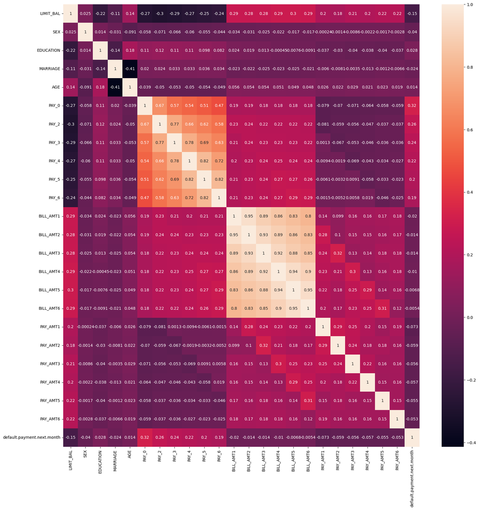

```python
plt.figure(figsize=(20,20))
sns.heatmap(credit_df.corr(), annot = True)
```

```python
credit_df.info()
```

```
<class 'pandas.core.frame.DataFrame'>
RangeIndex: 30000 entries, 0 to 29999
Data columns (total 24 columns):
 #   Column                      Non-Null Count  Dtype
---  ------                      --------------  -----
 0   LIMIT_BAL                   30000 non-null  float64
 1   SEX                         30000 non-null  int64
 2   EDUCATION                   30000 non-null  int64
 3   MARRIAGE                    30000 non-null  int64
 4   AGE                         30000 non-null  int64
 5   PAY_0                       30000 non-null  int64
 6   PAY_2                       30000 non-null  int64
 7   PAY_3                       30000 non-null  int64
 8   PAY_4                       30000 non-null  int64
 9   PAY_5                       30000 non-null  int64
```

[output cut: 16 more lines]

```python
categorical_column = credit_df[['SEX', 'EDUCATION','MARRIAGE']]
categorical_column
```

|  | SEX | EDUCATION | MARRIAGE |
| --- | --- | --- | --- |
| 0 | 2 | 2 | 1 |
| 1 | 2 | 2 | 2 |
| 2 | 2 | 2 | 2 |
| 3 | 2 | 2 | 1 |
| 4 | 1 | 2 | 1 |
| ... | ... | ... | ... |
| 29995 | 1 | 3 | 1 |
| 29996 | 1 | 3 | 2 |
| 29997 | 1 | 2 | 2 |
| 29998 | 1 | 3 | 1 |
| 29999 | 1 | 2 | 1 |

30000 rows × 3 columns

```python
numerical_column = credit_df[['LIMIT_BAL', 'AGE', 'PAY_0',
       'PAY_2', 'PAY_3', 'PAY_4', 'PAY_5', 'PAY_6', 'BILL_AMT1', 'BILL_AMT2',
       'BILL_AMT3', 'BILL_AMT4', 'BILL_AMT5', 'BILL_AMT6', 'PAY_AMT1',
       'PAY_AMT2', 'PAY_AMT3', 'PAY_AMT4', 'PAY_AMT5', 'PAY_AMT6']]
```

```python
numerical_column
```

|  | LIMIT_BAL | AGE | PAY_0 | PAY_2 | PAY_3 | PAY_4 | PAY_5 | PAY_6 | BILL_AMT1 | BILL_AMT2 | BILL_AMT3 | BILL_AMT4 | BILL_AMT5 | BILL_AMT6 | PAY_AMT1 | PAY_AMT2 | PAY_AMT3 | PAY_AMT4 | PAY_AMT5 | PAY_AMT6 |
| --- | --- | --- | --- | --- | --- | --- | --- | --- | --- | --- | --- | --- | --- | --- | --- | --- | --- | --- | --- | --- |
| 0 | 20000.0 | 24 | 2 | 2 | -1 | -1 | -2 | -2 | 3913.0 | 3102.0 | 689.0 | 0.0 | 0.0 | 0.0 | 0.0 | 689.0 | 0.0 | 0.0 | 0.0 | 0.0 |
| 1 | 120000.0 | 26 | -1 | 2 | 0 | 0 | 0 | 2 | 2682.0 | 1725.0 | 2682.0 | 3272.0 | 3455.0 | 3261.0 | 0.0 | 1000.0 | 1000.0 | 1000.0 | 0.0 | 2000.0 |
| 2 | 90000.0 | 34 | 0 | 0 | 0 | 0 | 0 | 0 | 29239.0 | 14027.0 | 13559.0 | 14331.0 | 14948.0 | 15549.0 | 1518.0 | 1500.0 | 1000.0 | 1000.0 | 1000.0 | 5000.0 |
| 3 | 50000.0 | 37 | 0 | 0 | 0 | 0 | 0 | 0 | 46990.0 | 48233.0 | 49291.0 | 28314.0 | 28959.0 | 29547.0 | 2000.0 | 2019.0 | 1200.0 | 1100.0 | 1069.0 | 1000.0 |
| 4 | 50000.0 | 57 | -1 | 0 | -1 | 0 | 0 | 0 | 8617.0 | 5670.0 | 35835.0 | 20940.0 | 19146.0 | 19131.0 | 2000.0 | 36681.0 | 10000.0 | 9000.0 | 689.0 | 679.0 |
| ... | ... | ... | ... | ... | ... | ... | ... | ... | ... | ... | ... | ... | ... | ... | ... | ... | ... | ... | ... | ... |
| 29995 | 220000.0 | 39 | 0 | 0 | 0 | 0 | 0 | 0 | 188948.0 | 192815.0 | 208365.0 | 88004.0 | 31237.0 | 15980.0 | 8500.0 | 20000.0 | 5003.0 | 3047.0 | 5000.0 | 1000.0 |
| 29996 | 150000.0 | 43 | -1 | -1 | -1 | -1 | 0 | 0 | 1683.0 | 1828.0 | 3502.0 | 8979.0 | 5190.0 | 0.0 | 1837.0 | 3526.0 | 8998.0 | 129.0 | 0.0 | 0.0 |
| 29997 | 30000.0 | 37 | 4 | 3 | 2 | -1 | 0 | 0 | 3565.0 | 3356.0 | 2758.0 | 20878.0 | 20582.0 | 19357.0 | 0.0 | 0.0 | 22000.0 | 4200.0 | 2000.0 | 3100.0 |
| 29998 | 80000.0 | 41 | 1 | -1 | 0 | 0 | 0 | -1 | -1645.0 | 78379.0 | 76304.0 | 52774.0 | 11855.0 | 48944.0 | 85900.0 | 3409.0 | 1178.0 | 1926.0 | 52964.0 | 1804.0 |
| 29999 | 50000.0 | 46 | 0 | 0 | 0 | 0 | 0 | 0 | 47929.0 | 48905.0 | 49764.0 | 36535.0 | 32428.0 | 15313.0 | 2078.0 | 1800.0 | 1430.0 | 1000.0 | 1000.0 | 1000.0 |

30000 rows × 20 columns

```python
from sklearn.preprocessing import OneHotEncoder
```

```python
encoder = OneHotEncoder()
one_hot_encoded = encoder.fit_transform(categorical_column)
```

```python
categorical_column = one_hot_encoded.toarray()
```

```python
categorical_column = pd.DataFrame(categorical_column)
```

```python
categorical_column
```

|  | 0 | 1 | 2 | 3 | 4 | 5 | 6 | 7 | 8 | 9 | 10 | 11 | 12 |
| --- | --- | --- | --- | --- | --- | --- | --- | --- | --- | --- | --- | --- | --- |
| 0 | 0.0 | 1.0 | 0.0 | 0.0 | 1.0 | 0.0 | 0.0 | 0.0 | 0.0 | 0.0 | 1.0 | 0.0 | 0.0 |
| 1 | 0.0 | 1.0 | 0.0 | 0.0 | 1.0 | 0.0 | 0.0 | 0.0 | 0.0 | 0.0 | 0.0 | 1.0 | 0.0 |
| 2 | 0.0 | 1.0 | 0.0 | 0.0 | 1.0 | 0.0 | 0.0 | 0.0 | 0.0 | 0.0 | 0.0 | 1.0 | 0.0 |
| 3 | 0.0 | 1.0 | 0.0 | 0.0 | 1.0 | 0.0 | 0.0 | 0.0 | 0.0 | 0.0 | 1.0 | 0.0 | 0.0 |
| 4 | 1.0 | 0.0 | 0.0 | 0.0 | 1.0 | 0.0 | 0.0 | 0.0 | 0.0 | 0.0 | 1.0 | 0.0 | 0.0 |
| ... | ... | ... | ... | ... | ... | ... | ... | ... | ... | ... | ... | ... | ... |
| 29995 | 1.0 | 0.0 | 0.0 | 0.0 | 0.0 | 1.0 | 0.0 | 0.0 | 0.0 | 0.0 | 1.0 | 0.0 | 0.0 |
| 29996 | 1.0 | 0.0 | 0.0 | 0.0 | 0.0 | 1.0 | 0.0 | 0.0 | 0.0 | 0.0 | 0.0 | 1.0 | 0.0 |
| 29997 | 1.0 | 0.0 | 0.0 | 0.0 | 1.0 | 0.0 | 0.0 | 0.0 | 0.0 | 0.0 | 0.0 | 1.0 | 0.0 |
| 29998 | 1.0 | 0.0 | 0.0 | 0.0 | 0.0 | 1.0 | 0.0 | 0.0 | 0.0 | 0.0 | 1.0 | 0.0 | 0.0 |
| 29999 | 1.0 | 0.0 | 0.0 | 0.0 | 1.0 | 0.0 | 0.0 | 0.0 | 0.0 | 0.0 | 1.0 | 0.0 | 0.0 |

30000 rows × 13 columns

```python
credit_df2 = pd.concat([categorical_column, numerical_column], axis = 1)
```

```python
credit_df2
```

|  | 0 | 1 | 2 | 3 | 4 | 5 | 6 | 7 | 8 | 9 | ... | BILL_AMT3 | BILL_AMT4 | BILL_AMT5 | BILL_AMT6 | PAY_AMT1 | PAY_AMT2 | PAY_AMT3 | PAY_AMT4 | PAY_AMT5 | PAY_AMT6 |
| --- | --- | --- | --- | --- | --- | --- | --- | --- | --- | --- | --- | --- | --- | --- | --- | --- | --- | --- | --- | --- | --- |
| 0 | 0.0 | 1.0 | 0.0 | 0.0 | 1.0 | 0.0 | 0.0 | 0.0 | 0.0 | 0.0 | ... | 689.0 | 0.0 | 0.0 | 0.0 | 0.0 | 689.0 | 0.0 | 0.0 | 0.0 | 0.0 |
| 1 | 0.0 | 1.0 | 0.0 | 0.0 | 1.0 | 0.0 | 0.0 | 0.0 | 0.0 | 0.0 | ... | 2682.0 | 3272.0 | 3455.0 | 3261.0 | 0.0 | 1000.0 | 1000.0 | 1000.0 | 0.0 | 2000.0 |
| 2 | 0.0 | 1.0 | 0.0 | 0.0 | 1.0 | 0.0 | 0.0 | 0.0 | 0.0 | 0.0 | ... | 13559.0 | 14331.0 | 14948.0 | 15549.0 | 1518.0 | 1500.0 | 1000.0 | 1000.0 | 1000.0 | 5000.0 |
| 3 | 0.0 | 1.0 | 0.0 | 0.0 | 1.0 | 0.0 | 0.0 | 0.0 | 0.0 | 0.0 | ... | 49291.0 | 28314.0 | 28959.0 | 29547.0 | 2000.0 | 2019.0 | 1200.0 | 1100.0 | 1069.0 | 1000.0 |
| 4 | 1.0 | 0.0 | 0.0 | 0.0 | 1.0 | 0.0 | 0.0 | 0.0 | 0.0 | 0.0 | ... | 35835.0 | 20940.0 | 19146.0 | 19131.0 | 2000.0 | 36681.0 | 10000.0 | 9000.0 | 689.0 | 679.0 |
| ... | ... | ... | ... | ... | ... | ... | ... | ... | ... | ... | ... | ... | ... | ... | ... | ... | ... | ... | ... | ... | ... |
| 29995 | 1.0 | 0.0 | 0.0 | 0.0 | 0.0 | 1.0 | 0.0 | 0.0 | 0.0 | 0.0 | ... | 208365.0 | 88004.0 | 31237.0 | 15980.0 | 8500.0 | 20000.0 | 5003.0 | 3047.0 | 5000.0 | 1000.0 |
| 29996 | 1.0 | 0.0 | 0.0 | 0.0 | 0.0 | 1.0 | 0.0 | 0.0 | 0.0 | 0.0 | ... | 3502.0 | 8979.0 | 5190.0 | 0.0 | 1837.0 | 3526.0 | 8998.0 | 129.0 | 0.0 | 0.0 |
| 29997 | 1.0 | 0.0 | 0.0 | 0.0 | 1.0 | 0.0 | 0.0 | 0.0 | 0.0 | 0.0 | ... | 2758.0 | 20878.0 | 20582.0 | 19357.0 | 0.0 | 0.0 | 22000.0 | 4200.0 | 2000.0 | 3100.0 |
| 29998 | 1.0 | 0.0 | 0.0 | 0.0 | 0.0 | 1.0 | 0.0 | 0.0 | 0.0 | 0.0 | ... | 76304.0 | 52774.0 | 11855.0 | 48944.0 | 85900.0 | 3409.0 | 1178.0 | 1926.0 | 52964.0 | 1804.0 |
| 29999 | 1.0 | 0.0 | 0.0 | 0.0 | 1.0 | 0.0 | 0.0 | 0.0 | 0.0 | 0.0 | ... | 49764.0 | 36535.0 | 32428.0 | 15313.0 | 2078.0 | 1800.0 | 1430.0 | 1000.0 | 1000.0 | 1000.0 |

30000 rows × 33 columns

```python
credit_df2.columns = credit_df2.columns.astype(str)
```

```python
from sklearn.preprocessing import MinMaxScaler
```

```python
scalar = MinMaxScaler()
```

```python
X = scalar.fit_transform(credit_df2)
```

```python
y = credit_df['default.payment.next.month']
```

```python
from sklearn.model_selection import train_test_split
```

```python
X_train, X_test, y_train, y_test = train_test_split(X, y, random_state = 0, test_size = 0.2)
```

Latih dan evaluasi model klasifikasi XG-Boost

```python
import xgboost as xgb
```

```python
xgb_model = xgb.XGBClassifier()
xgb_model.fit(X_train, y_train)
```

```
XGBClassifier(base_score=None, booster=None, callbacks=None,
              colsample_bylevel=None, colsample_bynode=None,
              colsample_bytree=None, device=None, early_stopping_rounds=None,
              enable_categorical=False, eval_metric=None, feature_types=None,
              gamma=None, grow_policy=None, importance_type=None,
              interaction_constraints=None, learning_rate=None, max_bin=None,
              max_cat_threshold=None, max_cat_to_onehot=None,
              max_delta_step=None, max_depth=None, max_leaves=None,
              min_child_weight=None, missing=nan, monotone_constraints=None,
              multi_strategy=None, n_estimators=None, n_jobs=None,
              num_parallel_tree=None, random_state=None, ...)
```

```python
y_predict = xgb_model.predict(X_test)
```

```python
y_predict
```

```
array([1, 0, 0, ..., 0, 1, 0])
```

```python
y_test
```

```
8225     0
10794    0
9163     0
26591    0
6631     0
        ..
12715    0
28867    0
3758     1
17842    0
9119     0
Name: default.payment.next.month, Length: 6000, dtype: int64
```

```python
from sklearn.metrics import classification_report
```

```python
print(classification_report(y_test, y_predict))
```

```
              precision    recall  f1-score   support

           0       0.85      0.94      0.89      4703
           1       0.65      0.38      0.48      1297

    accuracy                           0.82      6000
   macro avg       0.75      0.66      0.68      6000
weighted avg       0.80      0.82      0.80      6000
```

Latih dan evaluasi model klasifikasi Support Vector Machine

```python
from sklearn.svm import SVC
```

```python
svm_model = SVC(probability=True)
svm_model.fit(X_train, y_train)
```

```
SVC(probability=True)
```

```python
y_predict = svm_model.predict(X_test)
```

```python
y_test
```

```
8225     0
10794    0
9163     0
26591    0
6631     0
        ..
12715    0
28867    0
3758     1
17842    0
9119     0
Name: default.payment.next.month, Length: 6000, dtype: int64
```

```python
print(classification_report(y_test, y_predict))
```

```
              precision    recall  f1-score   support

           0       0.83      0.97      0.89      4703
           1       0.69      0.26      0.38      1297

    accuracy                           0.81      6000
   macro avg       0.76      0.61      0.63      6000
weighted avg       0.80      0.81      0.78      6000
```

Latih dan evaluasi model klasifikasi Naive Bayes

```python
from sklearn.naive_bayes import GaussianNB
```

```python
nb_model = GaussianNB()
nb_model.fit(X_train, y_train)
```

```
GaussianNB()
```

```python
y_predict = nb_model.predict(X_test)
```

```python
y_test
```

```
8225     0
10794    0
9163     0
26591    0
6631     0
        ..
12715    0
28867    0
3758     1
17842    0
9119     0
Name: default.payment.next.month, Length: 6000, dtype: int64
```

```python
print(classification_report(y_test, y_predict))
```

```
              precision    recall  f1-score   support

           0       0.91      0.10      0.18      4703
           1       0.23      0.97      0.37      1297

    accuracy                           0.28      6000
   macro avg       0.57      0.53      0.27      6000
weighted avg       0.76      0.28      0.22      6000
```

Latih dan evaluasi model klasifikasi Logistic Regression

```python
from sklearn.linear_model import LogisticRegression
```

```python
lr_model = LogisticRegression(max_iter = 10000)
lr_model.fit(X_train,y_train)
```

```
LogisticRegression(max_iter=10000)
```

```python
y_predict = lr_model.predict(X_test)
```

```python
y_test
```

```
8225     0
10794    0
9163     0
26591    0
6631     0
        ..
12715    0
28867    0
3758     1
17842    0
9119     0
Name: default.payment.next.month, Length: 6000, dtype: int64
```

```python
print(classification_report(y_test, y_predict))
```

```
              precision    recall  f1-score   support

           0       0.82      0.98      0.89      4703
           1       0.77      0.23      0.35      1297

    accuracy                           0.82      6000
   macro avg       0.79      0.60      0.62      6000
weighted avg       0.81      0.82      0.78      6000
```

Latih dan evaluasi model klasifikasi Random Forest

```python
from sklearn.ensemble import RandomForestClassifier
```

```python
rf_model = RandomForestClassifier()
rf_model.fit(X_train, y_train)
```

```
RandomForestClassifier()
```

```python
y_predict = rf_model.predict(X_test)
```

```python
print(classification_report(y_test, y_predict))
```

```
              precision    recall  f1-score   support

           0       0.84      0.95      0.89      4703
           1       0.66      0.37      0.47      1297

    accuracy                           0.82      6000
   macro avg       0.75      0.66      0.68      6000
weighted avg       0.80      0.82      0.80      6000
```

Latih dan evaluasi model klasifikasi K-Nearest Neighbors

```python
from sklearn.neighbors import KNeighborsClassifier
```

```python
knn_model = KNeighborsClassifier()
knn_model.fit(X_train, y_train)
```

```
KNeighborsClassifier()
```

```python
y_predict = knn_model.predict(X_test)
```

```python
print(classification_report(y_test, y_predict))
```

```
              precision    recall  f1-score   support

           0       0.83      0.92      0.87      4703
           1       0.53      0.34      0.41      1297

    accuracy                           0.79      6000
   macro avg       0.68      0.63      0.64      6000
weighted avg       0.77      0.79      0.77      6000
```

```python
from sklearn.metrics import roc_curve

fpr1, tpr1, thresh1 = roc_curve(y_test, xgb_model.predict_proba(X_test)[:, 1], pos_label = 1)
fpr2, tpr2, thresh2 = roc_curve(y_test, svm_model.predict_proba(X_test)[:, 1], pos_label = 1)
fpr3, tpr3, thresh3 = roc_curve(y_test, nb_model.predict_proba(X_test)[:, 1], pos_label = 1)
fpr4, tpr4, thresh4 = roc_curve(y_test, lr_model.predict_proba(X_test)[:, 1], pos_label = 1)
fpr5, tpr5, thresh5 = roc_curve(y_test, rf_model.predict_proba(X_test)[:, 1], pos_label = 1)
fpr6, tpr6, thresh6 = roc_curve(y_test, knn_model.predict_proba(X_test)[:, 1], pos_label = 1)
```

```python
from sklearn.metrics import roc_auc_score

auc_score1 = roc_auc_score(y_test, xgb_model.predict_proba(X_test)[:, 1])
auc_score2 = roc_auc_score(y_test, svm_model.predict_proba(X_test)[:, 1])
auc_score3 = roc_auc_score(y_test, nb_model.predict_proba(X_test)[:, 1])
auc_score4 = roc_auc_score(y_test, lr_model.predict_proba(X_test)[:, 1])
auc_score5 = roc_auc_score(y_test, rf_model.predict_proba(X_test)[:, 1])
auc_score6 = roc_auc_score(y_test, knn_model.predict_proba(X_test)[:, 1])
```

```python
print("XGB: ", auc_score1)
print("SVM: ", auc_score2)
print("NAIVE_BAYES: ", auc_score3)
print("LINEAR_REGRESSION: ", auc_score4)
print("RANDOM_FOREST: ", auc_score5)
print("KNN: ", auc_score6)
```

```
XGB:  0.7637615780606254
SVM:  0.7094111093314509
NAIVE_BAYES:  0.7341428583372775
LINEAR_REGRESSION:  0.7189789781322016
RANDOM_FOREST:  0.7678342585836136
KNN:  0.6973296298184644
```

[figure not shown]

```python
plt.plot(fpr1, tpr1, linestyle = "--", color = "orange", label = "XGB")
plt.plot(fpr2, tpr2, linestyle = "--", color = "red", label = "SVM")
plt.plot(fpr3, tpr3, linestyle = "--", color = "green", label = "NAIVE_BAYES")
plt.plot(fpr4, tpr4, linestyle = "--", color = "yellow", label = "LINEAR_REGRESSION")
plt.plot(fpr5, tpr5, linestyle = "--", color = "black", label = "RANDOM_FOREST")
plt.plot(fpr5, tpr5, linestyle = "--", color = "blue", label = "KNN")


plt.title('Receiver Operator Characteristics (ROC)')
plt.xlabel('False Positive Rate')
plt.ylabel('True Positive rate')

plt.legend(loc = 'best')
plt.savefig('ROC', dpi = 300)
plt.show()
```